# The Influence of Social Media Platforms; An Impact on People’s Identity.

Project 1 Report

500551998 500557761 500557738 500466658

University of Sydney | DATA1001-Wednesday 9am to 11am Carslaw Comp Lab 705-706| 03 2020

# 1 Executive Summary

- The aim of this report is to investigate the efficiency of social media platforms as a marketing presence and their impact on people’s identity
- The main discoveries are social media platforms are a major influential component in the marketing industry and have consequential effects on the shifting attitudes and perceptions of its users.

# 2 Full Report

## 2.1 Initial Data Analysis (IDA)

### 2.1.1 The Data Collection Process

Data for this report has been sourced through online custom designed survey forms on the Google Docs platform. Through which analysts have come to conclusions on the resulting patterns of the collected data. This process however may conflict with various ethical components and this ultimately affect the accuracy and/or reliability of sourced data. The necessary measures to ensure the ethical compliancy and reliability, survey forms were targeted at wide range of responders within the context of the stakeholder intentions. Natural variance in the race, background, familiarity of the survey topic was a expected criterion for data collection. Survey questions ensure inclusivity in areas such as gender and were appropriate option to respond on an ‘other’ basis.

[Survey Link](https://forms.gle/repoDjQyPvZcNjDk6)

### 2.1.2 Complexity of Data & Classification of Variables

The following data structure outlines the intial data types and default classifications of data collected

```r
SocialMedia = read.csv("C:\\Users\\User\\Desktop\\Data1001\\data\\project1.csv")
str(SocialMedia)
```

```
## 'data.frame':    53 obs. of  13 variables:
##  $ influence            : Factor w/ 2 levels "No","Yes": 2 2 2 2 2 2 2 2 2 2 ...
##  $ influence_type       : Factor w/ 4 levels "Behaviour","Dressing",..: 2 4 3 2 1 3 1 2 2 4 ...
##  $ sex                  : Factor w/ 2 levels "Female","Male": 2 2 2 2 2 1 1 1 2 1 ...
##  $ age                  : int  19 18 19 19 17 18 18 18 17 18 ...
##  $ media_platform       : Factor w/ 6 levels "Facebook","Instagram",..: 2 2 6 6 1 4 5 3 2 6 ...
##  $ purpose              : Factor w/ 5 levels "Business","Entertainment",..: 3 5 2 4 3 2 3 2 5 2 ...
##  $ time_spent           : Factor w/ 6 levels "Between 1 to 2 hours",..: 5 6 5 4 3 2 5 5 5 3 ...
##  $ assumptions_based_ads: Factor w/ 5 levels "Business","Females ",..: 4 2 5 3 1 2 1 2 2 4 ...
##  $ user_preference      : Factor w/ 4 levels "Appearance","Appearance;Lifestyle",..: 1 1 3 4 2 4 1 1 3 4 ...
##  $ post_frequency       : Factor w/ 9 levels "Do not post",..: 7 5 7 7 5 8 8 2 9 2 ...
##  $ usage_per_wk         : int  7 7 7 7 7 6 7 7 7 7 ...
##  $ impact_rate          : int  4 3 4 3 3 4 4 5 5 3 ...
##  $ addicted             : Factor w/ 3 levels "Maybe","No","Yes": 3 1 1 1 3 3 3 3 1 1 ...
```

The variables age, usage_per_wk and impact_rate need to be classed as num as this will reduce future issues when creating numerical and/or graphical summaries. As per the variables each has been labelled carefully for intuitive understanding of each type and its use. The variable assumptions_based_ads is to collect the type of user activity based ads on social media.

```r
SocialMedia = read.csv("C:\\Users\\User\\Desktop\\Data1001\\data\\project1.csv")
SocialMedia[4] <- lapply(SocialMedia[4], as.numeric)
SocialMedia[11] <- lapply(SocialMedia[11], as.numeric)
SocialMedia[12] <- lapply(SocialMedia[12], as.numeric)
str(SocialMedia)
```

```
## 'data.frame':    53 obs. of  13 variables:
##  $ influence            : Factor w/ 2 levels "No","Yes": 2 2 2 2 2 2 2 2 2 2 ...
##  $ influence_type       : Factor w/ 4 levels "Behaviour","Dressing",..: 2 4 3 2 1 3 1 2 2 4 ...
##  $ sex                  : Factor w/ 2 levels "Female","Male": 2 2 2 2 2 1 1 1 2 1 ...
##  $ age                  : num  19 18 19 19 17 18 18 18 17 18 ...
##  $ media_platform       : Factor w/ 6 levels "Facebook","Instagram",..: 2 2 6 6 1 4 5 3 2 6 ...
##  $ purpose              : Factor w/ 5 levels "Business","Entertainment",..: 3 5 2 4 3 2 3 2 5 2 ...
##  $ time_spent           : Factor w/ 6 levels "Between 1 to 2 hours",..: 5 6 5 4 3 2 5 5 5 3 ...
##  $ assumptions_based_ads: Factor w/ 5 levels "Business","Females ",..: 4 2 5 3 1 2 1 2 2 4 ...
##  $ user_preference      : Factor w/ 4 levels "Appearance","Appearance;Lifestyle",..: 1 1 3 4 2 4 1 1 3 4 ...
##  $ post_frequency       : Factor w/ 9 levels "Do not post",..: 7 5 7 7 5 8 8 2 9 2 ...
##  $ usage_per_wk         : num  7 7 7 7 7 6 7 7 7 7 ...
##  $ impact_rate          : num  4 3 4 3 3 4 4 5 5 3 ...
##  $ addicted             : Factor w/ 3 levels "Maybe","No","Yes": 3 1 1 1 3 3 3 3 1 1 ...
```

## 2.2 Is social media marketing as an influence on user activity and their perceptions effective?

Social media has been the pivotal platform for the marketing industry of the 21st century. The following data analysis provide insights into extent to which users are influenced consciously into shifted attitudes and perceptions. As shown in the graph below, even the majority of those who consciously respond that they are not affected by a social media presence have answered with median impact ratings between 4 and 2. This shows the apparent and subtle stigma evident in user perceptions on marketing and its efficiency. The median age for respondents to surveys being 19 and an approximate mean of 20 also suggests that the collected data reflects the perceptions of adolescent users of social media.

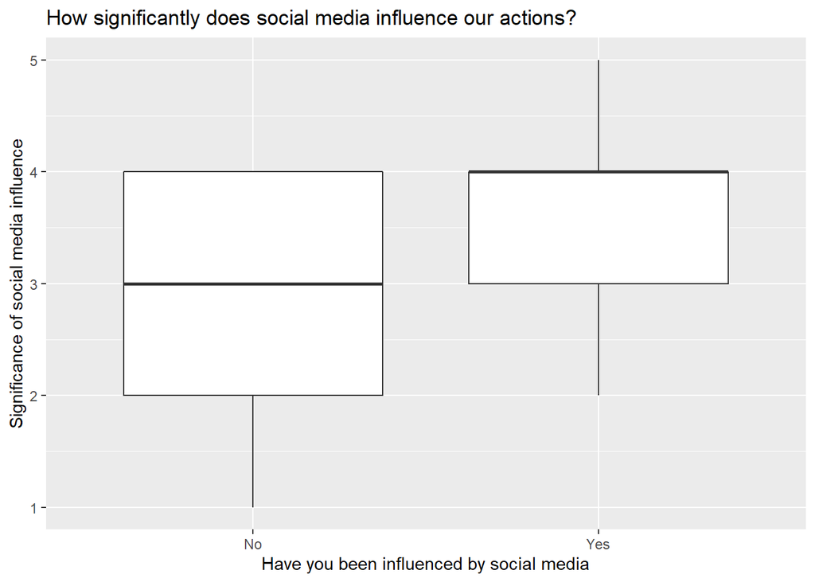

```r
library(ggplot2)

p4 = ggplot(data=SocialMedia, aes(x=factor(influence), y=impact_rate))
p4 + geom_boxplot() + ggtitle("How significantly does social media influence our actions?") + xlab("Have you been influenced by social media") + ylab("Significance of social media influence")
```

```r
#median
median(SocialMedia$age)
```

```
## [1] 19
```

Current trends and topics of interest on social media platforms are defined by user activity. This heavily monitored activity sol to third party companies for marketing and user-activity based analytic services. The related research on this topic correctly notes this notion “Users have a set of interests, which is deﬁned by information provided from various sources. Depending on the content, updates are directed to a set of users who will possibly be interested in receiving that content. (Baatarjav, Enkh-Amgalan & Dantu, Ram, 2011). To investigate the various areas targeted by analysing the first-hand responses of the user’s purpose for using social media; the graph below suggests how the areas of interest are ranked among user preference. With ‘dressing’ being a dominant component of the various interests. Which is no surprise as companies promote dressing, fitness and related areas through celebrity appeals for the sole reason to captivate user attention. The same research paper supports this notion “…it (social media) has become a platform that can be integrated into web applications, allowing for marketing via the users ‘social graph.” User activity is evidently driven by marketed product and ad services. As the previous graph suggests users themselves have agreed that it has influenced their actions either consciously or not.

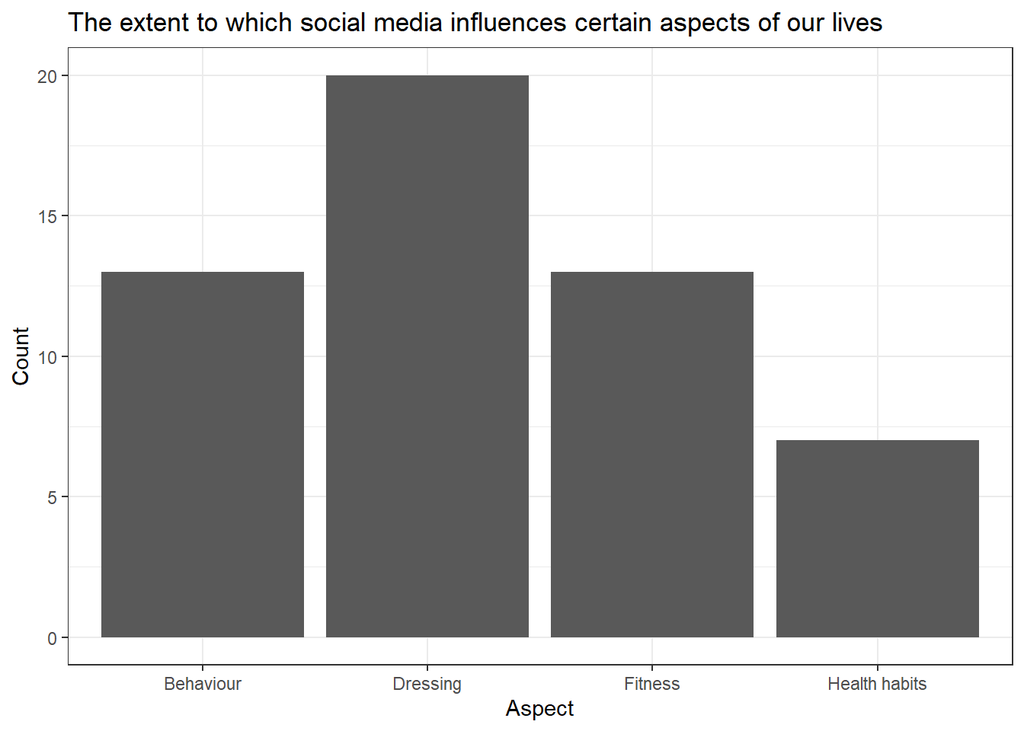

```r
library(ggplot2)
p = ggplot(SocialMedia, aes(x=factor(influence_type)))
p + geom_bar() + ggtitle("The extent to which social media influences certain aspects of our lives") + xlab("Aspect") + ylab("Count") + theme_bw()
```

| Time spent per day | No. of people |
| --- | --- |
| Between 1 to 2 hours | 8 |
| Between 2 to 3 hours | 13 |
| Between 3 to 4 hours | 11 |
| Between 4 to 6 hour | 9 |
| Greater than 6 hours | 9 |
| Less than 1 hour | 3 |

```r
#percentage of users using social media 7 days a week.

(48/length(SocialMedia$usage_per_wk == 7))*100
```

```
## [1] 90.56604
```

Therefore, it is evidently supported that marketing strategies do pose an integral part of what users are exposed to and their attitudes and perceptions as a result.

## 2.3 When people are labeled and stereotyped by others? Will they reassess themselves?

The stereotype mainly refers to people’s general and fixed view of a certain thing or object, which is generalized to believe that the thing or the whole has this feature, while individual differences are ignored.According to our data collected, we use ‘usage/week’, ‘user preference’ and ‘impact of people’ to analyze this question. The impact social media on people has a lot to do with how often they use it. As you can see from below graph, most people use social media every day (7 days). The usage per week affects how much stereotypes people have of others.

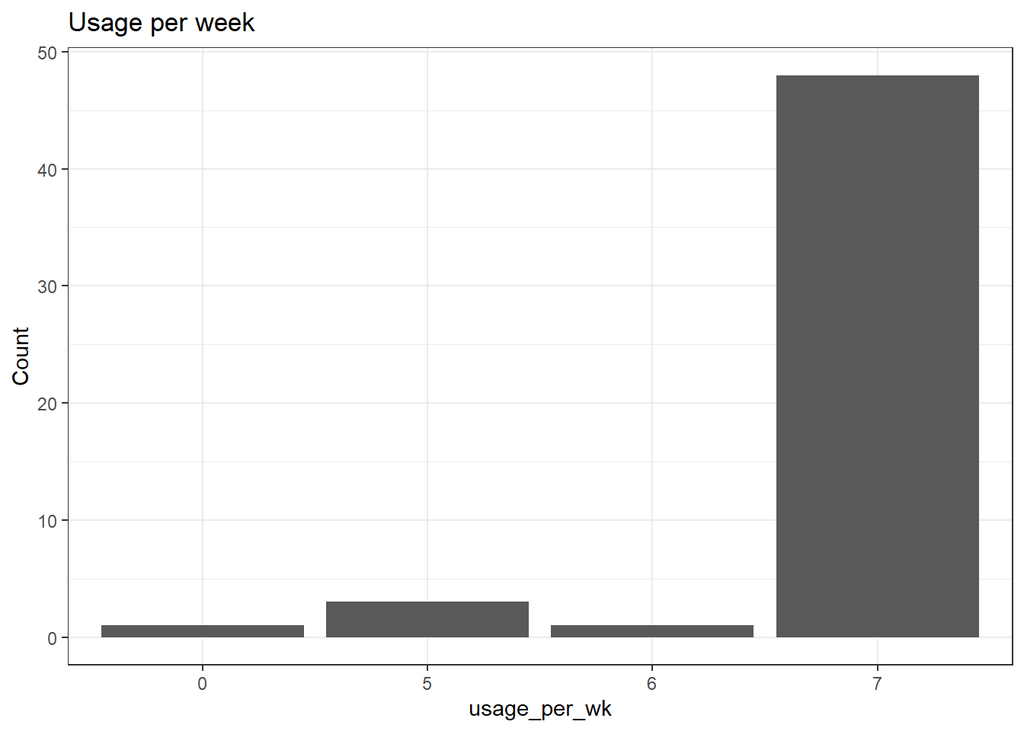

```r
library('ggplot2')
p = ggplot(SocialMedia, aes(x=factor(usage_per_wk)))
p + geom_bar() + ggtitle("Usage per week") + xlab("usage_per_wk") + ylab("Count") + theme_bw()
```

Similarly, the impact of social media on individuals also affects stereotypes. If individuals believe that the impact of social media is not enough to affect them, they do not always have a stereotype. This is also a very important reference factor as subjective.

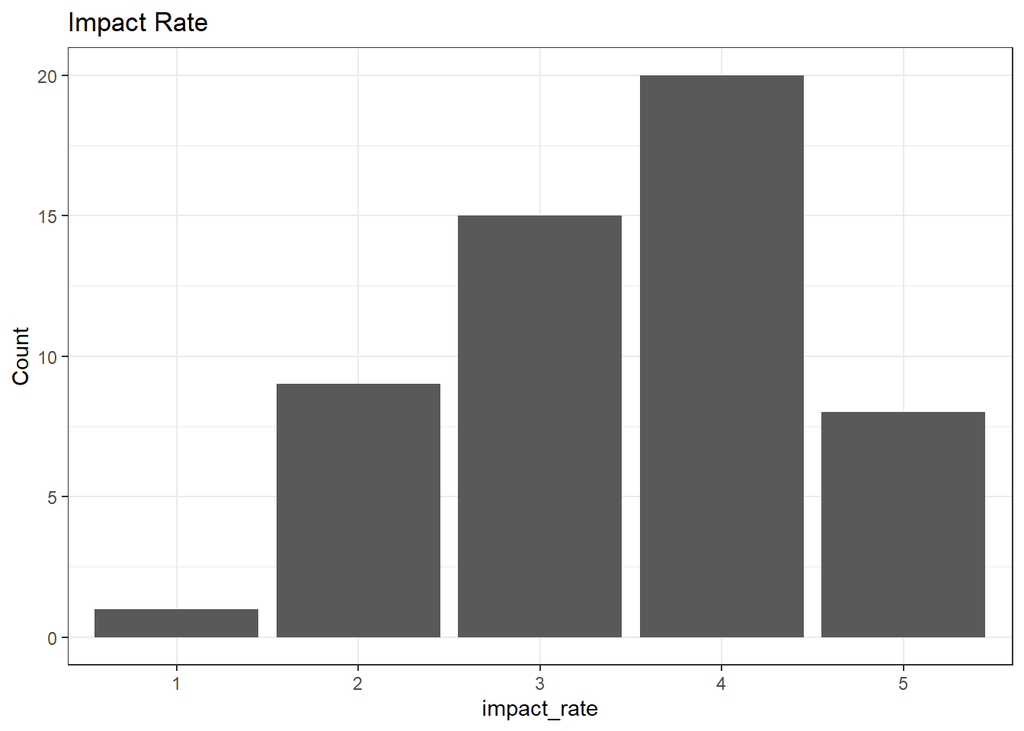

```r
library('ggplot2')
p2 = ggplot(SocialMedia, aes(x=factor(impact_rate)))
p2 + geom_bar() + ggtitle("Impact Rate") + xlab("impact_rate") + ylab("Count") + theme_bw()
```

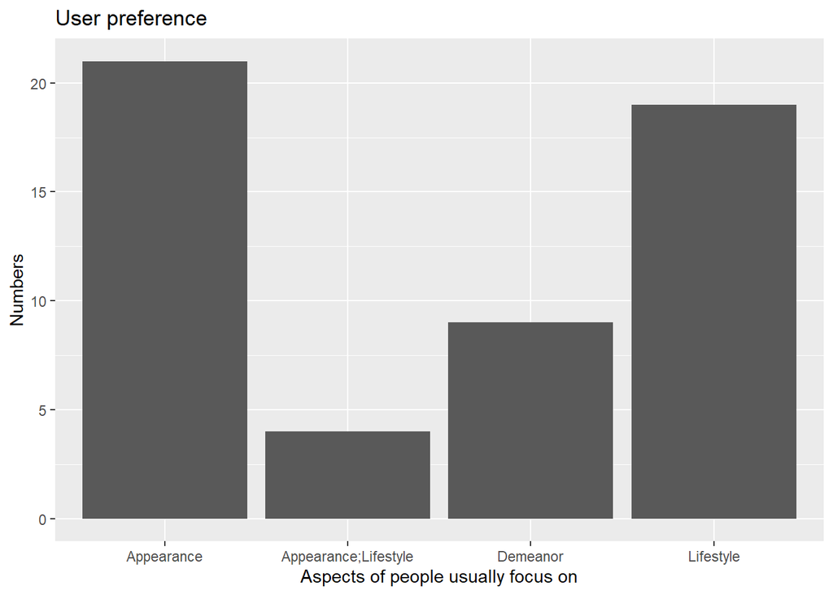

```r
qq = ggplot(data=SocialMedia, aes(x=factor(user_preference)))
qq + geom_bar() + ggtitle("User preference") + xlab("Aspects of people usually focus on") + ylab("Numbers")
```

*(Impact rate strength from 1 - 5, weak to strong)

Furthermore, when individuals use social media, the objects they focus on are also one of the important reference conditions for whether people will have a stereotyped impact. As we all know, when individuals use social media, such as instagram, tiktok, their main function is to post, people can post anything they want to post, such as dress, appearance and thus show their lifestyle and even wealth. This will directly become a source to influence people’s stereotypes. It can be seen from the image of user preference that individuals tend to focus on appearance when using social media. Obviously, appearance can directly make individuals stereotypes, such as dressing, etc.

# 3 References

Style: Harvard In-text(Baatarjav, Enkh-Amgalan & Dantu, Ram, 2011) Reasearch paper - Current and Future Trends in Social Media. 1384-1385. 10.1109/PASSAT/SocialCom.2011.125.